# R_script_RNAseq_Zymoseptoria

Cecile Lorrain

10/29/2019

###Packages

```r
library(DESeq2)
```

```r
library(ggplot2)
library(vegan)
library(colorspace)
library(tidyverse)
```

## RNAseq mapping and count attribution

```bash
# RNAseq mapping
### Using HITSAT2
hisat2-build ${unmasked_genome_file} /home/lorrain/RustTE/Pp/RNAseq/QC_Filtered_Raw_Data/${unmasked_genome_file}
#mapping
hisat2 -x ${unmasked_genome_file} \
 -U ${read_dir}${file}_1.fastq,${read_dir}${file}_2.fastq \
 -S ${outdir}${file}.hisat2.sam \
 --summary-file ${outdir}${file}.hisat2_summary.txt \
 --threads 4

# RNAseq count table
#with TEtranscritpsS:
TEcount --format BAM --mode uniq\
 -b S0213_Zt05_Ta_3_817_B.bam\
 --GTF Zt05_genes.gtf  --TE Zt05_TEs.gtf --project Zt05_uniq_A1
```

## Rarefaction curve

```r
Zt10<- read.csv("/home/cecile/Desktop/Postdoc_cecile/2_Zymo/1_Genomes/2-Transcriptome/Zt10_Gene_and_TEs_expression/Zt10_TE_gene_count.csv", header=TRUE, sep=",", row.names=1)
Zt05<- read.csv("/home/cecile/Desktop/Postdoc_cecile/2_Zymo/1_Genomes/2-Transcriptome/Zt05_Gene_and_TEs_expression/Zt05_TE_gene_count.csv", header=TRUE, sep=",", row.names=1)
Zt09<- read.csv("/home/cecile/Desktop/Postdoc_cecile/2_Zymo/1_Genomes/2-Transcriptome/Zt09_Gene_and_TEs_expression/In_planta/Zt09_TE_gene_count.csv", header=TRUE, sep=",", row.names=1)
Zt09 = Zt09[, -c(9,10)]

newZt10 <- as.data.frame(t(Zt10))
raremaxZt10 <- min(rowSums(newZt10))
newZt05 <- as.data.frame(t(Zt05))
raremaxZt05 <- min(rowSums(newZt05))
newZt09 <- as.data.frame(t(Zt09))
raremaxZt09 <- min(rowSums(newZt09))

col <- c("#de8d51", "#de8d51", "#94cc6a", "#94cc6a", "#6facdd", "#6facdd", "#d773c3", "#d773c3")

colMeans <- c("#de8d51",
              "#94cc6a",
              "#6facdd",
              "#d773c3")
lty <- c("solid")
pars <- expand.grid(col = col, lty = lty, stringsAsFactors = FALSE)
head(pars)
```

```
##       col   lty
## 1 #de8d51 solid
## 2 #de8d51 solid
## 3 #94cc6a solid
## 4 #94cc6a solid
## 5 #6facdd solid
## 6 #6facdd solid
```

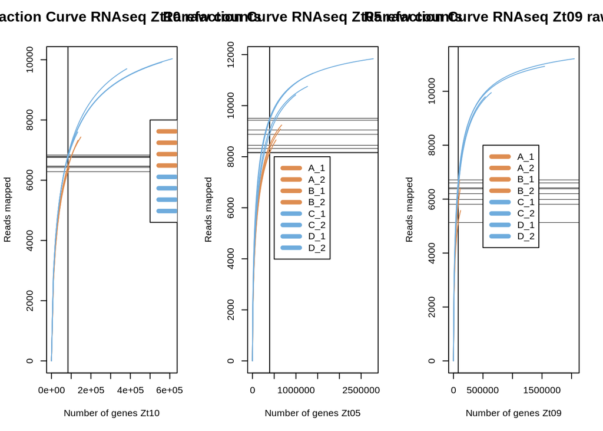

```r
par(mfrow=c(1,3))
out <- with(pars[1:33, ],
            rarecurve(newZt10, step = 10000, sample = raremaxZt10, col = c("#de8d51", "#de8d51", "#de8d51", "#de8d51", "#6facdd", "#6facdd", "#6facdd", "#6facdd"),
                      lty = lty, label = FALSE,  xlab = "Number of genes Zt10", ylab = "Reads mapped"))
mtext("Rarefaction Curve RNAseq Zt10 raw counts",
      side = 3, line = 2, cex = 1, font = 2)
legend(500000, 8000, legend=c("A_1", "A_2","B_1", "B_2", "C_1", "C_2",
                                 "D_1", "D_2"),

       col=c("#de8d51", "#de8d51", "#de8d51", "#de8d51", "#6facdd", "#6facdd", "#6facdd", "#6facdd"),
       lty=c("solid"), lwd = 5, cex=1)

out <- with(pars[1:33, ],
            rarecurve(newZt05, step = 10000, sample = raremaxZt05, col = c("#de8d51", "#de8d51", "#de8d51", "#de8d51", "#6facdd", "#6facdd", "#6facdd", "#6facdd"),
                      lty = lty, label = FALSE,  xlab = "Number of genes Zt05", ylab = "Reads mapped"))
mtext("Rarefaction Curve RNAseq Zt05 raw counts",
      side = 3, line = 2, cex = 1, font = 2)
legend(500000, 8000, legend=c("A_1", "A_2","B_1", "B_2", "C_1", "C_2",
                                 "D_1", "D_2"),

       col=c("#de8d51", "#de8d51", "#de8d51", "#de8d51", "#6facdd", "#6facdd", "#6facdd", "#6facdd"),
       lty=c("solid"), lwd = 5, cex=1)

out <- with(pars[1:33, ],
            rarecurve(newZt09, step = 10000, sample = raremaxZt09, col = c("#de8d51", "#de8d51", "#de8d51", "#de8d51", "#6facdd", "#6facdd", "#6facdd", "#6facdd"),
                      lty = lty, label = FALSE,  xlab = "Number of genes Zt09", ylab = "Reads mapped"))
mtext("Rarefaction Curve RNAseq Zt09 raw counts",
      side = 3, line = 2, cex = 1, font = 2)
legend(500000, 8000, legend=c("A_1", "A_2","B_1", "B_2", "C_1", "C_2",
                                 "D_1", "D_2"),

       col=c("#de8d51", "#de8d51", "#de8d51", "#de8d51", "#6facdd", "#6facdd", "#6facdd", "#6facdd"),
       lty=c("solid"), lwd = 5, cex=1)
```

####DESeq2 Matrix design

```r
DES_zt10=read.csv("/home/cecile/Desktop/Postdoc_cecile/2_Zymo/1_Genomes/2-Transcriptome/Zt10_Gene_and_TEs_expression/Zt10_TE_gene_count.csv", header=TRUE, sep=",", row.names=1)

Design_zt10=data.frame(row.names=colnames(DES_zt10))
Design_zt10$condition= c(rep("Biotrophic",4), rep("Necrotrophic",4))
Dmatrix_zt10=DESeqDataSetFromMatrix(countData = DES_zt10,
                               colData=Design_zt10,
                               design= ~condition)
### Extract normalized counts
Dmatrix_zt10_1 = estimateSizeFactors(Dmatrix_zt10)
Normalized_zt10 = counts(Dmatrix_zt10_1, normalized = T)
Means_zt10=data.frame(Biotrophic_Means=rowMeans(Normalized_zt10[,1:4]))
Means_zt10$Necrotrophic_Means=rowMeans(Normalized_zt10[,5:8])
head(Means_zt10)
```

```
##             Biotrophic_Means Necrotrophic_Means
## Zt10_0.1            0.000000          0.0000000
## Zt10_0.10           0.000000          0.1328217
## Zt10_0.100          0.000000          0.3300444
## Zt10_0.1000        11.005046         33.6124387
## Zt10_0.1001         6.860805          6.0265438
## Zt10_0.1002         3.426859          4.3024747
```

```r
DES_zt05=read.csv("/home/cecile/Desktop/Postdoc_cecile/2_Zymo/1_Genomes/2-Transcriptome/Zt05_Gene_and_TEs_expression/Zt05_TE_gene_count.csv", header=TRUE, sep=",", row.names=1) #make the geneID, the names each row)

Design_zt05=data.frame(row.names=colnames(DES_zt05))
Design_zt05$condition= c(rep("Biotrophic",4), rep("Necrotrophic",4))
Dmatrix_zt05=DESeqDataSetFromMatrix(countData = DES_zt05,
                               colData=Design_zt05,
                               design= ~condition)
Dmatrix_zt05_1 = estimateSizeFactors(Dmatrix_zt05)
Normalized_zt05 = counts(Dmatrix_zt05_1, normalized = T)
Means_zt05=data.frame(Biotrophic_Means=rowMeans(Normalized_zt05[,1:4]))
Means_zt05$Necrotrophic_Means=rowMeans(Normalized_zt05[,5:8])
head(Means_zt05)
```

```
##             Biotrophic_Means Necrotrophic_Means
## Zt05_0.1            0.000000           1.172404
## Zt05_0.10          17.066749           9.772230
## Zt05_0.100          0.000000           0.000000
## Zt05_0.1000         5.471546           6.812695
## Zt05_0.1001         4.074618           6.674662
## Zt05_0.1002        37.279006           9.272122
```

```r
DES_zt09=read.csv("/home/cecile/Desktop/Postdoc_cecile/2_Zymo/1_Genomes/2-Transcriptome/Zt09_Gene_and_TEs_expression/In_planta/Zt09_TE_gene_count.csv", header=TRUE, sep=",", row.names=1) #make the geneID, the names each row)
DES_zt09=DES_zt09[,-c(9,10)]

Design_zt09=data.frame(row.names=colnames(DES_zt09))
Design_zt09$condition= c(rep("Biotrophic",4), rep("Necrotrophic",4))
Dmatrix_zt09=DESeqDataSetFromMatrix(countData = DES_zt09,
                               colData=Design_zt09,
                               design= ~condition)
Dmatrix_zt09_1 = estimateSizeFactors(Dmatrix_zt09)
Normalized_zt09 = counts(Dmatrix_zt09_1, normalized = T)
Means_zt09=data.frame(Biotrophic_Means=rowMeans(Normalized_zt09[,1:4]))
Means_zt09$Necrotrophic_Means=rowMeans(Normalized_zt09[,5:8])
#Means_zt09$InVitro_Means=rowMeans(Normalized_zt09[,9:10])
head(Means_zt09)
```

```
##              Biotrophic_Means Necrotrophic_Means
## Zt09_1_00001        0.0000000          0.0000000
## Zt09_1_00010        2.6735371          2.6124624
## Zt09_1_00100        2.4990124          0.9047753
## Zt09_1_01000        0.0000000          1.7097035
## Zt09_1_01001        0.6935085          2.6001767
## Zt09_1_01002        6.7377719         10.9151517
```

####DESeq2 Diagnostic plots #####Rlog transformed data

```r
#Data transformation for PCA, Matrix distance, plots,...
rld_zt10 <- rlog(Dmatrix_zt10)
rld_zt05 <- rlog(Dmatrix_zt05)
rld_zt09 <- rlog(Dmatrix_zt09)

#Extract transformed data in a table and .csv:
rlogMat_zt10 <- assay(rld_zt10)
rlogMat_zt05 <- assay(rld_zt05)
rlogMat_zt09 <- assay(rld_zt09)
```

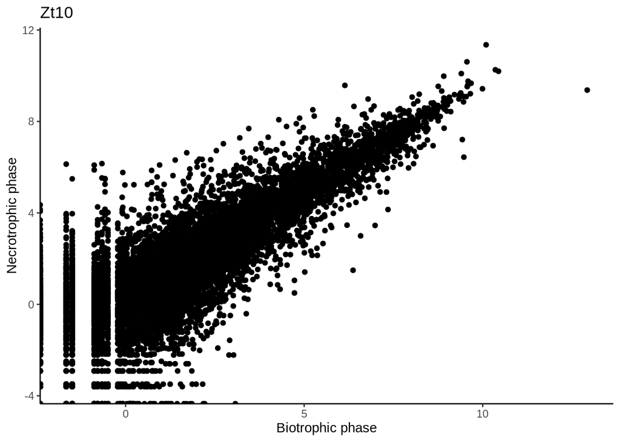

```r
#Plots_means on normalized counts
library(grid)
library(gridExtra)
Means_zt09 = Means_zt09[, -c(3)]

logmeans_zt10 = log2(Means_zt10)
logmeans_zt05 = log2(Means_zt05)
logmeans_zt09 = log2(Means_zt09)

p <- ggplot(logmeans_zt10, aes(x = Biotrophic_Means, y = Necrotrophic_Means)) + geom_point() + xlab("Biotrophic phase") + ylab("Necrotrophic phase") + theme_classic() + ggtitle("Zt10")
p
```

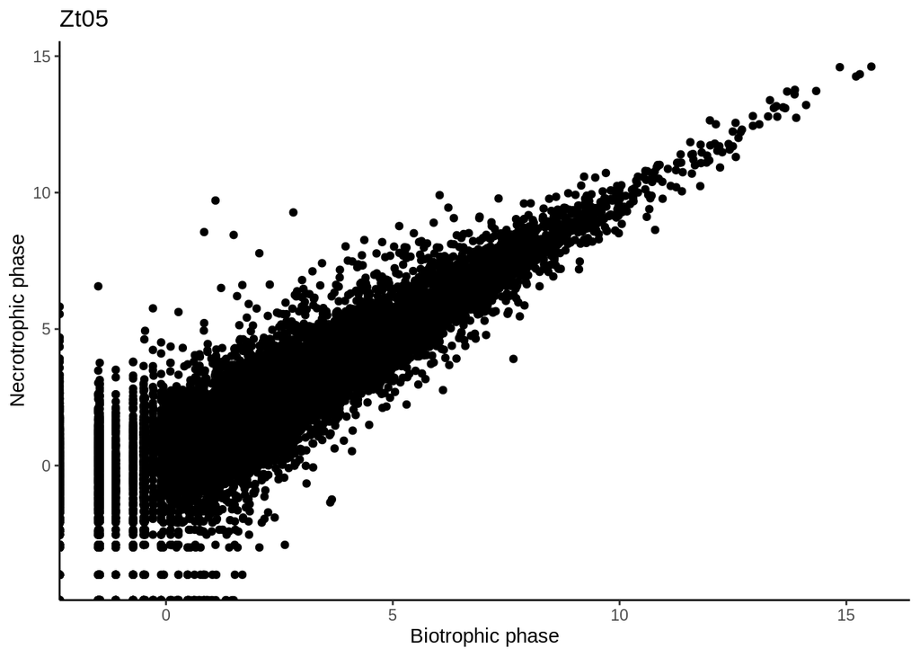

```r
p1 <- ggplot(logmeans_zt05, aes(x = Biotrophic_Means, y = Necrotrophic_Means)) + geom_point() + xlab("Biotrophic phase") + ylab("Necrotrophic phase") + theme_classic() + ggtitle("Zt05")
p1
```

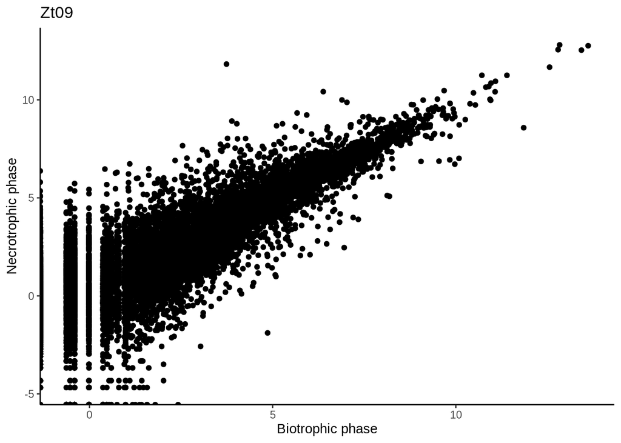

```r
p2 <- ggplot(logmeans_zt09, aes(x = Biotrophic_Means, y = Necrotrophic_Means)) + geom_point() + xlab("Biotrophic phase") + ylab("Necrotrophic phase") + theme_classic() + ggtitle("Zt09")
p2
```

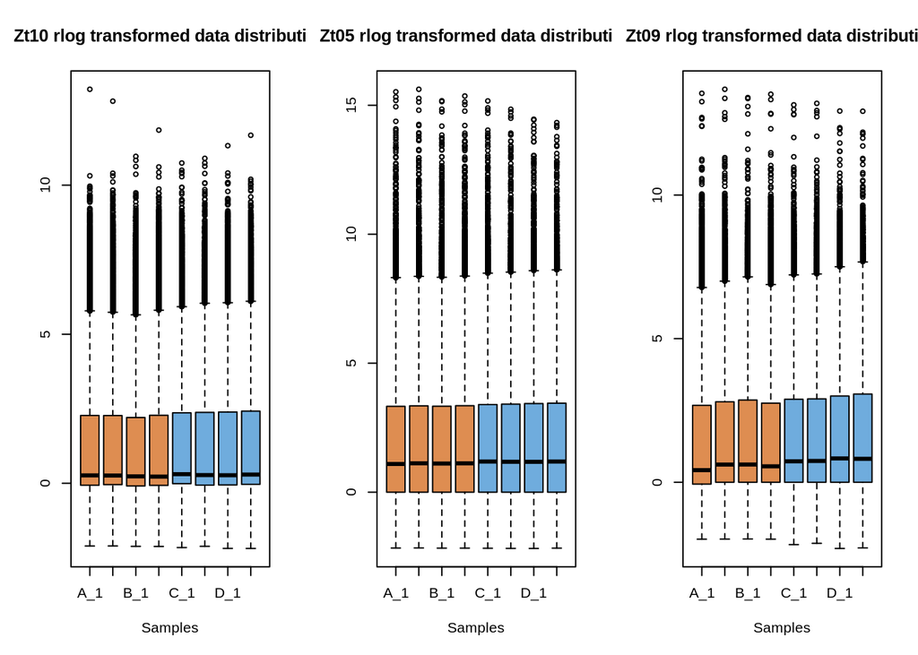

```r
#Boxplots
col <- c("#de8d51", "#de8d51", "#de8d51", "#de8d51", "#6facdd", "#6facdd", "#6facdd", "#6facdd")

par(mfrow=c(1,3))
boxplot(rlogMat_zt10, cex.axis=1, font.axis="Arial Black", font.main="Arial Black", font.lab="Arial Black", col=col)
title(main="Zt10 rlog transformed data distribution", xlab="Samples" )
boxplot(rlogMat_zt05, cex.axis=1, font.axis="Arial Black", font.main="Arial Black", font.lab="Arial Black", col=col)
title(main="Zt05 rlog transformed data distribution", xlab="Samples" )
boxplot(rlogMat_zt09, cex.axis=1, font.axis="Arial Black", font.main="Arial Black", font.lab="Arial Black", col=col)
title(main="Zt09 rlog transformed data distribution", xlab="Samples" )
```

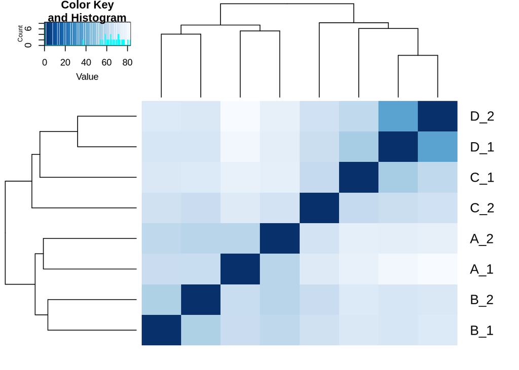

```r
##Sample distances normalized counts
library(gplots)
library(RColorBrewer)
sampleDists_zt10 <- dist(t(assay(rld_zt10)))
sampleDistMatrix_zt10 <- as.matrix(sampleDists_zt10)
rownames(sampleDistMatrix_zt10) <- paste( colnames(DES_zt10))
colors <- colorRampPalette( rev(brewer.pal(9, "Blues")) )(255)
hc_zt10 <- hclust(sampleDists_zt10)

sampleDists_zt05 <- dist(t(assay(rld_zt05)))
sampleDistMatrix_zt05 <- as.matrix(sampleDists_zt05)
rownames(sampleDistMatrix_zt05) <- paste( colnames(DES_zt05))
hc_zt05 <- hclust(sampleDists_zt05)

sampleDists_zt09 <- dist(t(assay(rld_zt09)))
sampleDistMatrix_zt09 <- as.matrix(sampleDists_zt09)
rownames(sampleDistMatrix_zt09) <- paste( colnames(DES_zt09))
hc_zt09 <- hclust(sampleDists_zt09)

par(mfrow=c(1,3))
heatmap.2(sampleDistMatrix_zt10, Rowv=as.dendrogram(hc_zt10),
           symm=TRUE, trace="none", col=colors,
           margins=c(2,5), labCol=FALSE )
```

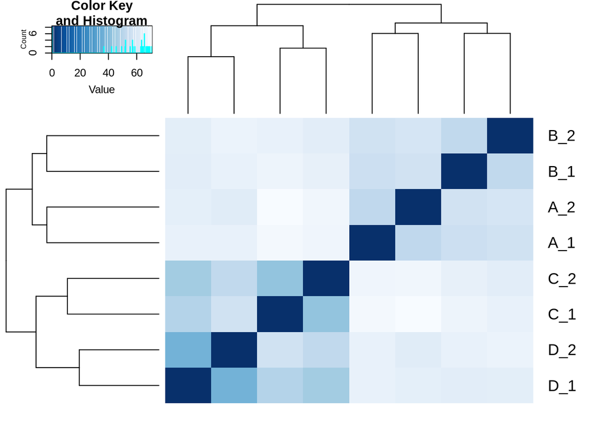

```r
heatmap.2(sampleDistMatrix_zt05, Rowv=as.dendrogram(hc_zt05),
           symm=TRUE, trace="none", col=colors,
           margins=c(2,5), labCol=FALSE )
```

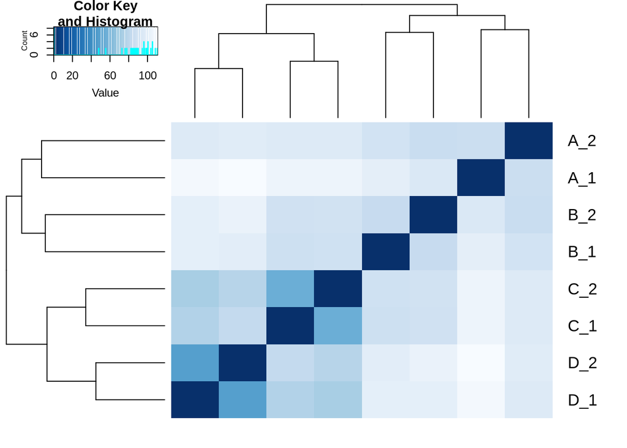

```r
heatmap.2(sampleDistMatrix_zt09, Rowv=as.dendrogram(hc_zt09),
           symm=TRUE, trace="none", col=colors,
           margins=c(2,5), labCol=FALSE )
```

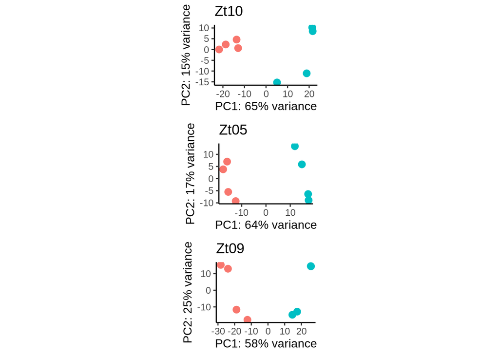

```r
#PCA
p <- plotPCA(rld_zt10, intgroup ="condition") + scale_colour_hue(breaks=c("Biotrophic_Means","Necrotrophic_Means")) +
  ggtitle("Zt10") + theme_classic(base_size = 12) + geom_point(size = 2)
p1 <- plotPCA(rld_zt05, intgroup ="condition") + scale_colour_hue(breaks=c("Biotrophic_Means","Necrotrophic_Means")) +
  ggtitle("Zt05") + theme_classic(base_size = 12) + geom_point(size = 2)
p2 <- plotPCA(rld_zt09, intgroup ="condition") + scale_colour_hue(breaks=c("Biotrophic_Means","Necrotrophic_Means")) +
  ggtitle("Zt09") + theme_classic(base_size = 12) + geom_point(size = 2)
grid.arrange(p, p1, p2)
```

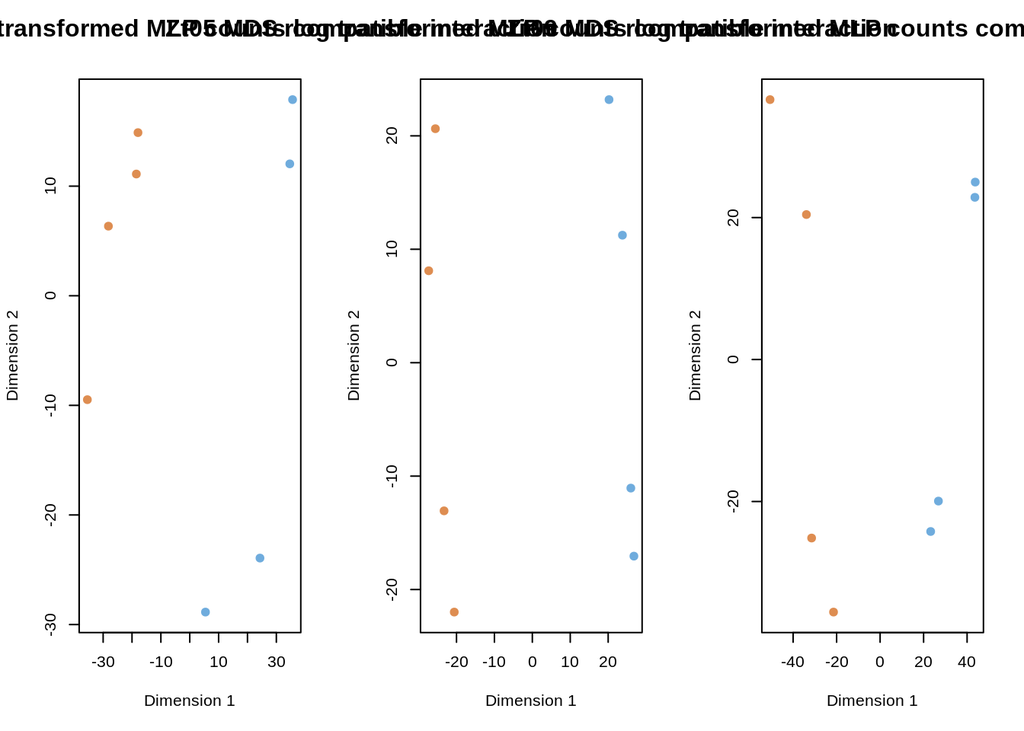

```r
col <- c("#de8d51", "#de8d51", "#de8d51", "#de8d51", "#6facdd", "#6facdd", "#6facdd", "#6facdd")
mds_zt10 <- as.data.frame(colData(rld_zt10))
mds_zt10 <- cbind(cmdscale(sampleDistMatrix_zt10))
mds_zt05 <- as.data.frame(colData(rld_zt05))
mds_zt05 <- cbind(cmdscale(sampleDistMatrix_zt05))
mds_zt09 <- as.data.frame(colData(rld_zt09))
mds_zt09 <- cbind(cmdscale(sampleDistMatrix_zt09))


par(mfrow=c(1,3))
plot(mds_zt10, col= col, pch = 19, xlab="Dimension 1", ylab="Dimension 2")
mtext("Zt10 MDS rlog transformed MLP counts compatible interaction",
      side = 3, line = 2, cex = 1, font = 2)
plot(mds_zt05, col= col, pch = 19, xlab="Dimension 1", ylab="Dimension 2")
mtext("Zt05 MDS rlog transformed MLP counts compatible interaction",
      side = 3, line = 2, cex = 1, font = 2)
plot(mds_zt09, col= col, pch = 19, xlab="Dimension 1", ylab="Dimension 2")
mtext("Zt09 MDS rlog transformed MLP counts compatible interaction",
      side = 3, line = 2, cex = 1, font = 2)
```

##DESeq2 Differential Expression analysis

```r
library(data.table)
DES_zt09=read.csv("/home/cecile/Desktop/Postdoc_cecile/2_Zymo/1_Genomes/2-Transcriptome/Zt09_Gene_and_TEs_expression/Zt09_gene_noTE_count.csv", header=TRUE, sep=",", dec = ".", row.names = 1)

coldata_zt09=data.frame(row.names=colnames(DES_zt09))
coldata_zt09$condition = c(rep("Biotrophic",4), rep("Necrotrophic",4), rep("In_vitro", 2))
coldata_zt09$stage = c(rep("A",2), rep("B",2),rep("C",2), rep("D",2), rep("Axenic", 2))

#make sure the conditions are factors
coldata_zt09$condition = as.factor(coldata_zt09$condition)
#Design
ddsCond_zt09 <- DESeqDataSetFromMatrix(countData = DES_zt09,
                                  colData=coldata_zt09,
                                  design= formula(~ condition))
dds <- DESeq(ddsCond_zt09)
DmatrixCond_zt09 <- estimateSizeFactors(ddsCond_zt09)
Normalized_zt09 = counts(DmatrixCond_zt09, normalized=T)

keep <- rowSums(counts(ddsCond_zt09)) >= 1
ddsCond_zt09_filtered <- ddsCond_zt09[keep,]
design(ddsCond_zt09_filtered) <- formula(~ condition)
ddsCond_zt09_filtered <- DESeq(ddsCond_zt09_filtered)
ntd <- normTransform(ddsCond_zt09_filtered)

#write.table(Normalized_zt09, "/home/cecile/Desktop/Postdoc_cecile/2_Zymo/1_Genomes/2-Transcriptome/zt09_Normalized_counts_condition.csv", sep = "\t")

#DEGs
resCond_zt09_filtered<- results(ddsCond_zt09_filtered)
resCond_zt09_filtered$symbol <- mcols(ddsCond_zt09_filtered)$symbol
head(resCond_zt09_filtered[order(resCond_zt09_filtered$padj),], 4)
```

```
## log2 fold change (MLE): condition Necrotrophic vs Biotrophic
## Wald test p-value: condition Necrotrophic vs Biotrophic
## DataFrame with 4 rows and 6 columns
##                       baseMean    log2FoldChange             lfcSE
##                      <numeric>         <numeric>         <numeric>
## Zt09_1_01819  554.719937770505  3.99410820548814 0.288567681776991
## Zt09_7_00069  1079.86487941313 -3.30690674751216 0.267921335786374
## Zt09_2_00917  168.874209177714  4.69504866334716 0.407697879948629
## Zt09_13_00367 184.408799173799  5.02604926894115 0.484409624011798
##                            stat               pvalue                 padj
##                       <numeric>            <numeric>            <numeric>
## Zt09_1_01819   13.8411487415796 1.43888578969429e-43 9.14555807929689e-40
## Zt09_7_00069  -12.3428271877119 5.32525533128523e-35 1.69236614428245e-31
## Zt09_2_00917   11.5159997004123 1.09581263990089e-30 2.32166171307002e-27
## Zt09_13_00367  10.3756181128613  3.2013387771284e-25 5.08692731685703e-22
```

```r
resultsNames(ddsCond_zt09_filtered)
```

```
## [1] "Intercept"
## [2] "condition_In_vitro_vs_Biotrophic"
## [3] "condition_Necrotrophic_vs_Biotrophic"
```

```r
resNecro_vs_Bio <- results(ddsCond_zt09_filtered, name="condition_Necrotrophic_vs_Biotrophic", test="Wald")
sum(resNecro_vs_Bio$padj < 0.05, na.rm=TRUE)
```

```
## [1] 711
```

```r
sum(resNecro_vs_Bio$padj < 0.05 & resNecro_vs_Bio$log2FoldChange > 0 ,na.rm=TRUE)
```

```
## [1] 467
```

```r
sum(resNecro_vs_Bio$padj < 0.05 & resNecro_vs_Bio$log2FoldChange < 0 ,na.rm=TRUE)
```

```
## [1] 244
```

```r
#write.table(as.data.frame(resCond_zt09_filtered),file="/home/cecile/Desktop/Postdoc_cecile/2_Zymo/1_Genomes/2-Transcriptome/zt09_Biotrophic_vs_Necrotrophic_DEGs_gene.csv", sep ="\t")
```

## TPM normalization

TPM is very similar to RPKM and FPKM. The only difference is the order of operations. Here’s how you calculate TPM:

1- Divide the read counts by the length of each gene in kilobases. This gives you reads per kilobase (RPK). 2- Count up all the RPK values in a sample and divide this number by 1,000,000. This is your “per million” scaling factor. 3- Divide the RPK values by the “per million” scaling factor. This gives you TPM.

So you see, when calculating TPM, the only difference is that you normalize for gene length first, and then normalize for sequencing depth second. However, the effects of this difference are quite profound.

When you use TPM, the sum of all TPMs in each sample are the same. This makes it easier to compare the proportion of reads that mapped to a gene in each sample. In contrast, with RPKM and FPKM, the sum of the normalized reads in each sample may be different, and this makes it harder to compare samples directly.

```r
# Use count matrix:
length_zt10 = read.csv("/home/cecile/Desktop/Postdoc_cecile/2_Zymo/1_Genomes/2-Transcriptome/Zt10_Gene_and_TEs_expression/Zt10_gene_length.csv", header=TRUE, sep=",", row.names=1, dec = ".")
length_zt05 = read.csv("/home/cecile/Desktop/Postdoc_cecile/2_Zymo/1_Genomes/2-Transcriptome/Zt05_Gene_and_TEs_expression/Zt05_gene_length.csv", header=TRUE, sep=",", row.names=1, dec = ".")
length_zt09 = read.csv("/home/cecile/Desktop/Postdoc_cecile/2_Zymo/1_Genomes/2-Transcriptome/Zt09_Gene_and_TEs_expression/Zt09_gene_length.csv", header=TRUE, sep=",", row.names=1, dec = ".")

length_zt10 = as.matrix(length_zt10)
length_zt05 = as.matrix(length_zt05)
length_zt09 = as.matrix(length_zt09)

DES_zt10 = as.matrix(DES_zt10)
DES_zt05 = as.matrix(DES_zt05)
DES_zt09 = as.matrix(DES_zt09)

# function to calculate TMP:
# Normalize for gene length:
x_zt10 <- DES_zt10/c(length_zt10)
x_zt05 <- DES_zt05/c(length_zt05)
x_zt09 <- DES_zt09/c(length_zt09)
# Normalize to read depth (here depth = colSums of the count matrix):
tpm_zt10 <- t(t(x_zt10)*1e6/colSums(x_zt10))
tpm_zt05 <- t(t(x_zt05)*1e6/colSums(x_zt05))
tpm_zt09 <- t(t(x_zt09)*1e6/colSums(x_zt09))

#Means for TPM biotrophic and Necrotrophic
TPM_zt10=data.frame(Biotrophic_TPM=rowMeans(tpm_zt10[,1:4]))
TPM_zt10$Necrotrophic_TPM=rowMeans(tpm_zt10[,5:8])
#write.table(TPM_zt10, file="/home/cecile/Desktop/Postdoc_cecile/2_Zymo/1_Genomes/2-Transcriptome/zt10_Biotrophic_Necrotrophic_TPM.csv", sep ="\t")

TPM_zt05=data.frame(Biotrophic_TPM=rowMeans(tpm_zt05[,1:4]))
TPM_zt05$Necrotrophic_TPM=rowMeans(tpm_zt05[,5:8])
#write.table(TPM_zt05, file="/home/cecile/Desktop/Postdoc_cecile/2_Zymo/1_Genomes/2-Transcriptome/zt05_Biotrophic_Necrotrophic_TPM.csv", sep ="\t")

TPM_zt09=data.frame(Biotrophic_TPM=rowMeans(tpm_zt09[,1:4]))
TPM_zt09$Necrotrophic_TPM=rowMeans(tpm_zt09[,5:8])
TPM_zt09$InVitro_TPM=rowMeans(tpm_zt09[,9:10])
```

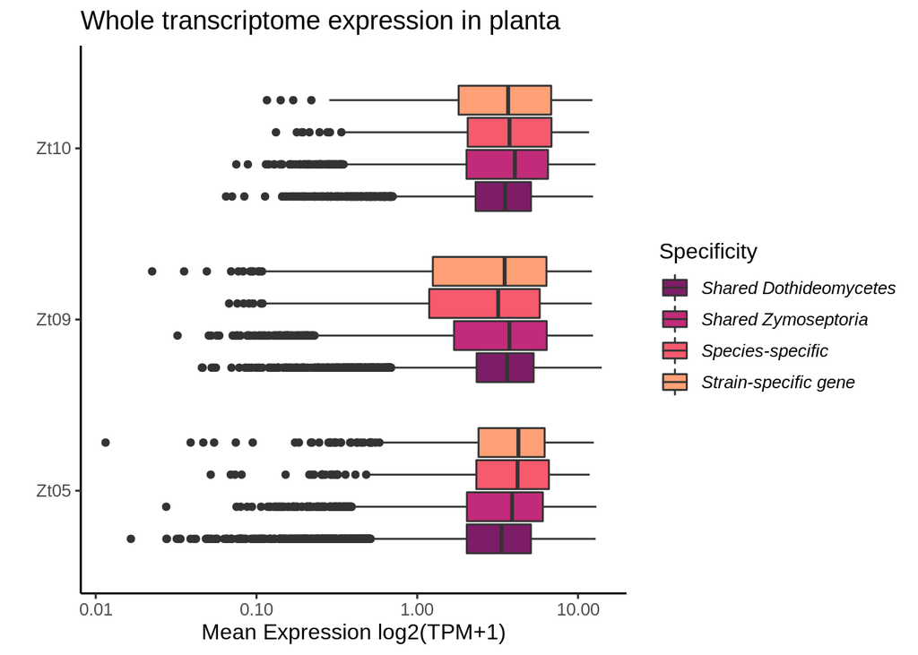

```r
#boxplot
big = read.csv("/home/cecile/Desktop/Postdoc_cecile/2_Zymo/1_Genomes/FINAL_ZYMO_GENE_ANNOTATIONS.csv", header = T, sep = ",")
Zt_tmp = read.csv("/home/cecile/Desktop/Postdoc_cecile/2_Zymo/1_Genomes/2-Transcriptome/TPM_zt.csv", header = T, sep =",")
DEG = read.csv("/home/cecile/Desktop/Postdoc_cecile/2_Zymo/1_Genomes/2-Transcriptome/zt_DEGs.csv", header = T, sep = ",")

big2 = merge(big, Zt_tmp, by = "Protein_ID")
big2 = merge(big2, DEG, by = "Protein_ID")
big2$TPM1 = (big2$Zymo_TPM + 1)
big2$TPM_log = log2(big2$TPM1)


#Boxplot
q <- sequential_hcl(5, "SunsetDark")

ggplot(big2, aes(x=Sample, y=TPM_log)) +
  geom_boxplot(aes(fill = Specificity)) +
  theme_classic(base_size = 12) + theme(legend.text = element_text(face = "italic")) +
  ylab("Mean Expression log2(TPM+1)") + xlab("") + scale_y_continuous(trans='log10') +
  coord_flip() +  scale_fill_manual(values = c(q[c(1:4)])) +
  ggtitle("Whole transcriptome expression in planta")
```

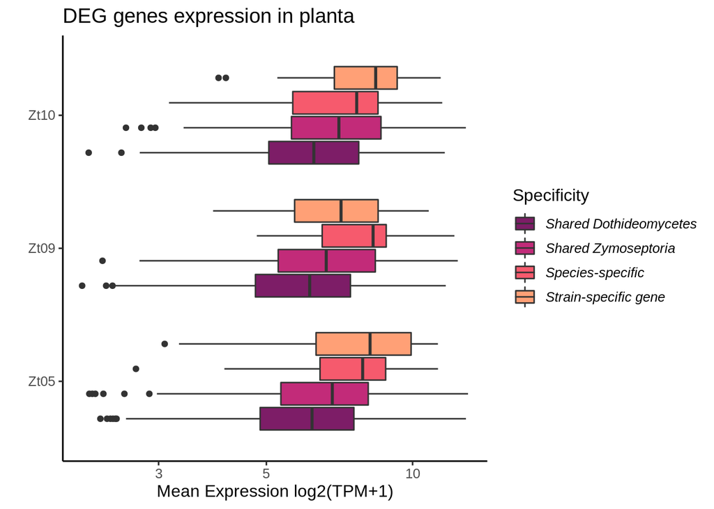

```r
deg = big2 %>% filter(padj < 0.05)
ggplot(deg, aes(x=Sample, y=TPM_log)) +
  geom_boxplot(aes(fill = Specificity)) +
  theme_classic(base_size = 12) + theme(legend.text = element_text(face = "italic")) +
  ylab("Mean Expression log2(TPM+1)") + xlab("") + scale_y_continuous(trans='log10') +
  coord_flip() +  scale_fill_manual(values = c(q[c(1:4)])) +
  ggtitle("DEG genes expression in planta")
```